# Scientifc Python ver.2

#### Author: Juhyung Kang

#### e-mail: jhkang@astro.snu.ac.kr

Python is the useful high-level computational language for science, machine learing, IoT and web design. The language is quite simliar with the MATLAB but the license is free and no need to access LAN. There are many user communities.

From this second tutorial we learn the basic command line for the data handling and graphics.

This tutorial is uploaded on the **'Tutorials'** menu at https://jhkang.netlify.com

The basic resource of python for scientist is available in [Scipy Lecture Notes](https://scipy-lectures.org/).

#### Required packages

- [Python](https://www.python.org/) v2.7 or 3.6+
- [NumPy](http://www.numpy.org/)
- [SciPy](https://www.scipy.org/)
- [matplotlib](https://matplotlib.org/)
- [Astropy](http://www.astropy.org/)

# 1. Array handling

To call an array in python, we should import the [numpy](https://www.numpy.org)

```python
import numpy as np
```

## 1.1. Manual construction

```python
a = np.array([1,2,3,4,5])
```

```python
a
```

```
array([1, 2, 3, 4, 5])
```

```python
a.shape
```

```
(5,)
```

```python
a.ndim
```

```
1
```

```python
a.dtype
```

```
dtype('int32')
```

```python
a = a.astype(float)
```

```python
a.dtype
```

```
dtype('float64')
```

```python
a = np.array([1,2,3,4,5],dtype=float)
```

**Slicing**

```python
a[3]
```

```
4.0
```

```python
a[-1]
```

```
5.0
```

```python
a[0:2]
```

```
array([1., 2.])
```

```python
a[2:5]
```

```
array([3., 4., 5.])
```

```python
a[:]
```

```
array([1., 2., 3., 4., 5.])
```

```python
a[0:5:2]
```

```
array([1., 3., 5.])
```

```python
a[-1:0:-1]
```

```
array([5., 4., 3., 2.])
```

```python
a[::-1]
```

```
array([5., 4., 3., 2., 1.])
```

**Convert this row array to the column array**

```python
col = a[:,None]
```

```python
col
```

```
array([[1.],
       [2.],
       [3.],
       [4.],
       [5.]])
```

```python
col.shape
```

```
(5, 1)
```

```python
newarr = a[None,:,None]
```

```python
newarr
```

```
array([[[1.],
        [2.],
        [3.],
        [4.],
        [5.]]])
```

```python
newarr.shape
```

```
(1, 5, 1)
```

**Array appending**

```python
a = np.append(a,[6,7])
```

```python
a
```

```
array([1., 2., 3., 4., 5., 6., 7.])
```

```python
b = np.concatenate([a, a])
```

```python
b
```

```
array([1., 2., 3., 4., 5., 6., 7., 1., 2., 3., 4., 5., 6., 7.])
```

> Note) np.array(1) and np.array([1]) are different

```python
a1 = np.array(1)
a2 = np.array([1])
```

```python
a1
```

```
array(1)
```

```python
a2
```

```
array([1])
```

```python
a1[0]
```

```
---------------------------------------------------------------------------
IndexError                                Traceback (most recent call last)
<ipython-input-31-24bd6a1fc18f> in <module>()
----> 1 a1[0]

IndexError: too many indices for array
```

```python
a2[0]
```

```
1
```

```python
a1 = a1.flatten()
```

```python
a1
```

```
array([1])
```

```python
a1[0]
```

```
1
```

**Make 2D array.**

```python
arr2d = np.array([[1,2,3],[4,5,6]], dtype=float)
```

```python
arr2d
```

```
array([[1., 2., 3.],
       [4., 5., 6.]])
```

```python
arr2d[0]
```

```
array([1., 2., 3.])
```

```python
arr2d[0,0]
```

```
1.0
```

```python
arr2d[0][0]
```

```
1.0
```

## 1.2. Array generator

From the **[np.arange](https://docs.scipy.org/doc/numpy/reference/generated/numpy.arange.html)** or **[np.linspace](https://docs.scipy.org/doc/numpy/reference/generated/numpy.linspace.html)**, we can generate the evenly spaced array automatically.

**np.arange**([start,]stop,[step,]dtype=None)  
Return evenly spaced values within a given interval.

**np.linspace**(start, stop, num=50, endpoint=True, retstep=False, dtype=None, axis=0)  
Return evenly spaced numbers over a specified interval.

**arange**

```python
ara = np.arange(6)
```

```python
ara
```

```
array([0, 1, 2, 3, 4, 5])
```

```python
ara2 = np.arange(2,6,0.5)
```

```python
ara2
```

```
array([2. , 2.5, 3. , 3.5, 4. , 4.5, 5. , 5.5])
```

**linspace**

```python
alin = np.linspace(0,6,5)
```

```python
alin
```

```
array([0. , 1.5, 3. , 4.5, 6. ])
```

## 1.3. Broadcasting

The high adventage for array handling in python is **broadcasting**.

Basic operations on numpy arrays (addition, etc.) are elementwise This works on arrays of the same size. Nevertheless, It’s also possible to do operations on arrays of different sizes if NumPy can transform these arrays so that they all have the same size: this conversion is called **broadcasting.**

```python
a = np.linspace(1,9,9)
b = np.arange(45).reshape(5,9)
```

```python
a
```

```
array([1., 2., 3., 4., 5., 6., 7., 8., 9.])
```

```python
b
```

```
array([[ 0,  1,  2,  3,  4,  5,  6,  7,  8],
       [ 9, 10, 11, 12, 13, 14, 15, 16, 17],
       [18, 19, 20, 21, 22, 23, 24, 25, 26],
       [27, 28, 29, 30, 31, 32, 33, 34, 35],
       [36, 37, 38, 39, 40, 41, 42, 43, 44]])
```

```python
a+b
```

```
array([[ 1.,  3.,  5.,  7.,  9., 11., 13., 15., 17.],
       [10., 12., 14., 16., 18., 20., 22., 24., 26.],
       [19., 21., 23., 25., 27., 29., 31., 33., 35.],
       [28., 30., 32., 34., 36., 38., 40., 42., 44.],
       [37., 39., 41., 43., 45., 47., 49., 51., 53.]])
```

```python
acol = a[:,None]
```

```python
acol.shape
```

```
(9, 1)
```

```python
a*acol
```

```
array([[ 1.,  2.,  3.,  4.,  5.,  6.,  7.,  8.,  9.],
       [ 2.,  4.,  6.,  8., 10., 12., 14., 16., 18.],
       [ 3.,  6.,  9., 12., 15., 18., 21., 24., 27.],
       [ 4.,  8., 12., 16., 20., 24., 28., 32., 36.],
       [ 5., 10., 15., 20., 25., 30., 35., 40., 45.],
       [ 6., 12., 18., 24., 30., 36., 42., 48., 54.],
       [ 7., 14., 21., 28., 35., 42., 49., 56., 63.],
       [ 8., 16., 24., 32., 40., 48., 56., 64., 72.],
       [ 9., 18., 27., 36., 45., 54., 63., 72., 81.]])
```

```python
one=np.ones([9,1])
```

```python
one
```

```
array([[1.],
       [1.],
       [1.],
       [1.],
       [1.],
       [1.],
       [1.],
       [1.],
       [1.]])
```

```python
a*one
```

```
array([[1., 2., 3., 4., 5., 6., 7., 8., 9.],
       [1., 2., 3., 4., 5., 6., 7., 8., 9.],
       [1., 2., 3., 4., 5., 6., 7., 8., 9.],
       [1., 2., 3., 4., 5., 6., 7., 8., 9.],
       [1., 2., 3., 4., 5., 6., 7., 8., 9.],
       [1., 2., 3., 4., 5., 6., 7., 8., 9.],
       [1., 2., 3., 4., 5., 6., 7., 8., 9.],
       [1., 2., 3., 4., 5., 6., 7., 8., 9.],
       [1., 2., 3., 4., 5., 6., 7., 8., 9.]])
```

## 1.4. Basic reduction

```python
x = np.arange(5)
```

```python
x
```

```
array([0, 1, 2, 3, 4])
```

```python
x.sum()
```

```
10
```

```python
x.mean()
```

```
2.0
```

**Sum by rows and by columns:**

```python
x2 = np.arange(30).reshape(5,6)
```

```python
x2
```

```
array([[ 0,  1,  2,  3,  4,  5],
       [ 6,  7,  8,  9, 10, 11],
       [12, 13, 14, 15, 16, 17],
       [18, 19, 20, 21, 22, 23],
       [24, 25, 26, 27, 28, 29]])
```

```python
x2.shape
```

```
(5, 6)
```

```python
x2.sum(0)  # colums (first dimension)
```

```
array([60, 65, 70, 75, 80, 85])
```

```python
x2.sum(1)  # rows (second dimension)
```

```
array([ 15,  51,  87, 123, 159])
```

# 2. Graphics

From this session, we learn how to visulize the arrays by using [matplotlib](https://matplotlib.org/) package.

At first, enable interactive plots:

```python
matplotlib
```

```
Using matplotlib backend: Qt5Agg
```

Let's import the 2D plotting package, *matplotlib*.

```python
import matplotlib.pyplot as plt
```

## 2.1. 1D plotting

```python
x = np.arange(10)
```

```python
y = x**2
```

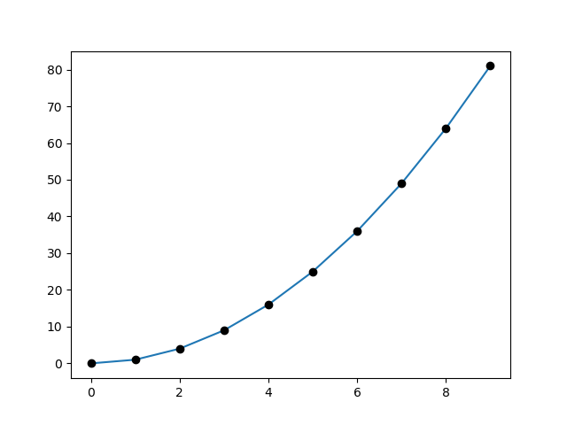

```python
plt.plot(x,y)
```

```python
plt.plot(x,y,'o',color='black')
```

## 2.2. 2D plotting

```python
x2 = x * x[:,None]
```

```python
x2
```

```
array([[ 0,  0,  0,  0,  0,  0,  0,  0,  0,  0],
       [ 0,  1,  2,  3,  4,  5,  6,  7,  8,  9],
       [ 0,  2,  4,  6,  8, 10, 12, 14, 16, 18],
       [ 0,  3,  6,  9, 12, 15, 18, 21, 24, 27],
       [ 0,  4,  8, 12, 16, 20, 24, 28, 32, 36],
       [ 0,  5, 10, 15, 20, 25, 30, 35, 40, 45],
       [ 0,  6, 12, 18, 24, 30, 36, 42, 48, 54],
       [ 0,  7, 14, 21, 28, 35, 42, 49, 56, 63],
       [ 0,  8, 16, 24, 32, 40, 48, 56, 64, 72],
       [ 0,  9, 18, 27, 36, 45, 54, 63, 72, 81]])
```

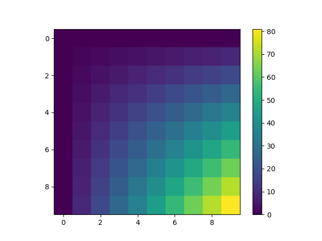

```python
plt.imshow(x2)
```

```python
plt.colorbar()
```

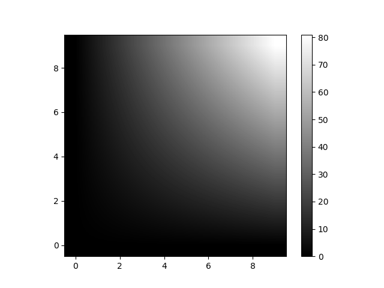

```python
im = plt.imshow(x2,origin='lower', cmap=plt.cm.jet)
```

```python
plt.colorbar(im)
```

```python
im.set_cmap(plt.cm.gray)
```

```python
im.set_interpolation('bilinear')
```

## 2.3. 3D plotting

**Plot 2D data on 3D plot**

At first we import 3D axes

```python
from mpl_toolkits.mplot3d import Axes3D
```

```python
x = np.linspace(-4,4,40)
xx, yy = np.meshgrid(x,x)
R = np.sqrt(xx**2 +yy**2)
zz = np.sin(R)
data = zz
```

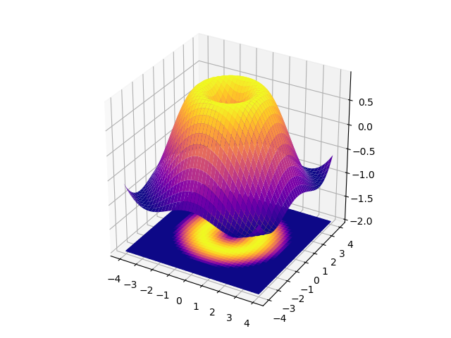

```python
fig = plt.figure()
ax = fig.gca(projection='3d')
ax.set_aspect('equal')
```

```python
ax.plot_surface(xx,yy,data,cmap=plt.cm.plasma)
```

```python
plane = np.ones((data.shape))
```

```python
ax.plot_surface(xx,yy,plane*-2,facecolors=plt.cm.plasma(data/data.max()),shade=False)
```

```python
fig.tight_layout()
```

## 2.4. Subplots with GridSpec

Easy way to add subplots is use the matplotlib subplots function (see the [Lecture](https://scipy-lectures.org/intro/matplotlib/index.html#subplots). However, it is difficult to make details. There is another option to create subplots: *gridspec*

In this section we learn how to use the one of the gridspec class: [ImgaeGrid](https://matplotlib.org/api/_as_gen/mpl_toolkits.axes_grid1.axes_grid.ImageGrid.html) (see [example](https://matplotlib.org/mpl_toolkits/axes_grid/users/overview.html)) :

```python
from mpl_toolkits.axes_grid1 import ImageGrid
```

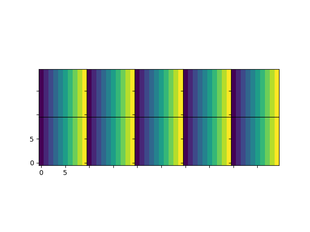

```python
fig = plt.figure()
grid = ImageGrid(fig, 111, nrows_ncols=(2, 5),
                 axes_pad=0, share_all=True,
                 label_mode='1')
```

```python
img = np.arange(10) * np.ones((10,10))
```

```python
# grid[i].imshow(images)
for i in grid:
    i.imshow(img,origin='lower')
```

# 3. AstroPy

AstroPy is the useful python package for astronomers. From this we learn how to read the fits file and its header.

## 3.1. Read Fits file

Download the [sample fits](https://jhkang.netlify.com/files/HorseHead.fits) file.

```python
from astropy.io import fits
```

**Read fits**

```python
data = fits.getdata('C:/Users/User/Downloads/HorseHead.fits')
```

```python
data.shape
```

```
(893, 891)
```

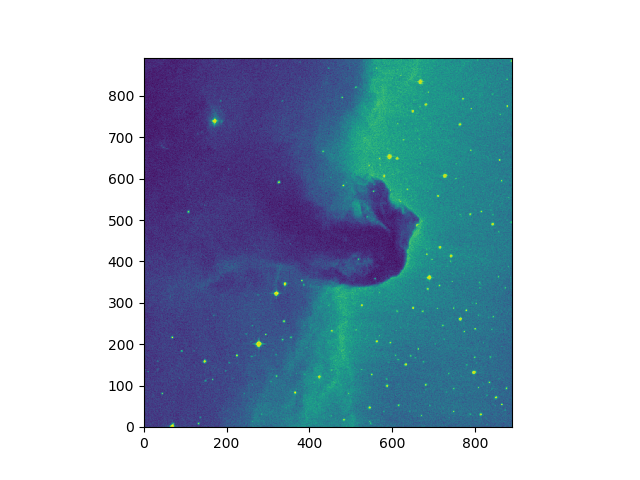

```python
plt.imshow(data,origin='lower')
```

[figure not shown]

```python
plt.imshow(data.T,origin='lower')
```

[figure not shown]

```python
plt.imshow(data.T[:,::-1],origin='lower')
```

**Read header**

```python
h = fits.getheader('C:/Users/User/Downloads/HorseHead.fits')
```

```python
h
```

```
SIMPLE  =                    T /FITS: Compliance
BITPIX  =                   16 /FITS: I*2 Data
NAXIS   =                    2 /FITS: 2-D Image Data
NAXIS1  =                  891 /FITS: X Dimension
NAXIS2  =                  893 /FITS: Y Dimension
EXTEND  =                    T /FITS: File can contain extensions
DATE    = '2014-01-09        '  /FITS: Creation Date
ORIGIN  = 'STScI/MAST'         /GSSS: STScI Digitized Sky Survey
SURVEY  = 'SERC-ER '           /GSSS: Sky Survey
REGION  = 'ER768   '           /GSSS: Region Name
PLATEID = 'A0JP    '           /GSSS: Plate ID
SCANNUM = '01      '           /GSSS: Scan Number
DSCNDNUM= '00      '           /GSSS: Descendant Number
TELESCID=                    4 /GSSS: Telescope ID
BANDPASS=                   36 /GSSS: Bandpass Code
COPYRGHT= 'AAO/ROE '           /GSSS: Copyright Holder
SITELAT =              -31.277 /Observatory: Latitude
SITELONG=              210.934 /Observatory: Longitude
TELESCOP= 'UK Schmidt - Doubl' /Observatory: Telescope
INSTRUME= 'Photographic Plate' /Detector: Photographic Plate
EMULSION= 'IIIaF   '           /Detector: Emulsion
FILTER  = 'OG590   '           /Detector: Filter
PLTSCALE=                67.20 /Detector: Plate Scale arcsec per mm
PLTSIZEX=              355.000 /Detector: Plate X Dimension mm
PLTSIZEY=              355.000 /Detector: Plate Y Dimension mm
PLATERA =        85.5994550000 /Observation: Field centre RA degrees
PLATEDEC=       -4.94660910000 /Observation: Field centre Dec degrees
PLTLABEL= 'OR14052 '           /Observation: Plate Label
DATE-OBS= '1990-12-22T13:49:00' /Observation: Date/Time
EXPOSURE=                 65.0 /Observation: Exposure Minutes
PLTGRADE= 'AD2     '           /Observation: Plate Grade
OBSHA   =             0.158333 /Observation: Hour Angle
OBSZD   =              26.3715 /Observation: Zenith Distance
AIRMASS =              1.11587 /Observation: Airmass
REFBETA =        66.3196420000 /Observation: Refraction Coeff
REFBETAP=     -0.0820000000000 /Observation: Refraction Coeff
REFK1   =        6423.52290000 /Observation: Refraction Coeff
REFK2   =       -102122.550000 /Observation: Refraction Coeff
CNPIX1  =                12237 /Scan: X Corner
CNPIX2  =                19965 /Scan: Y Corner
```

[output cut: 106 more lines]

```
CTYPE2  = 'DEC--TAN          ' /GetImage: Dec-Gnomic projection
CRPIX2  =           447.000000 /GetImage: Y reference pixel
CRVAL2  =            -2.458265 /GetImage: Dec of reference pixel
CUNIT2  = 'deg               ' /Getimage: degrees
CD1_1   =        -0.0002802651 /GetImage: rotation matrix coefficient
CD1_2   =         0.0000003159 /GetImage: rotation matrix coefficient
CD2_1   =         0.0000002767 /GetImage: rotation matrix coefficient
CD2_2   =         0.0002798187 /GetImage: rotation matrix coefficient
OBJECT  = 'data              ' /GetImage: Requested Object Name
DATAMIN =                 3759 /GetImage: Minimum returned pixel value
DATAMAX =                22918 /GetImage: Maximum returned pixel value
OBJCTRA = '05 41 06.000      ' /GetImage: Requested Right Ascension (J2000)
OBJCTDEC= '-02 27 30.00      ' /GetImage: Requested Declination (J2000)
OBJCTX  =             12682.48 /GetImage: Requested X on plate (pixels)
OBJCTY  =             20411.37 /GetImage: Requested Y on plate (pixels)
```

```python
h['exposure']
```

```
65.0
```

```python
h['date-obs']
```

```
'1990-12-22T13:49:00'
```

## 3.1. Unit handling

As we use the astropy.units and constants module, we can easily calculate the physical parameters

```python
import astropy.constants as con
```

```python
con.R_sun
```

$6.957 \times 10^{8} \; \mathrm{m}$

```python
con.R_sun.cgs
```

$6.957 \times 10^{10} \; \mathrm{cm}$

```python
con.R_sun.to('nm')
```

$6.957 \times 10^{17} \; \mathrm{nm}$

```python
con.c
```

$2.9979246 \times 10^{8} \; \mathrm{\frac{m}{s}}$

```python
con.au / con.c
```

$499.00478 \; \mathrm{s}$

```python
(con.au / con.c).to('min')
```

$8.3167464 \; \mathrm{min}$

**unit module**

```python
import astropy.units as u
```

```python
u.cm
```

$\mathrm{cm}$

```python
1*u.cm
```

$1 \; \mathrm{cm}$

```python
con.au + 1e13*u.cm
```

$2.4959787 \times 10^{11} \; \mathrm{m}$

**Time module**

```python
from astropy.time import Time
```

```python
date = h['date-obs']
```

```python
date
```

```
'1990-12-22T13:49:00'
```

```python
t = Time(date)
```

```python
t
```

```
<Time object: scale='utc' format='isot' value=1990-12-22T13:49:00.000>
```

```python
t + 1*u.year
```

```
<Time object: scale='utc' format='isot' value=1991-12-22T19:48:59.000>
```

```python
t.jd  # julian date
```

```
2448248.0756944446
```